# Risk Factor Analysis

## Outcome Variable

**Outcome Variable:** whz

## Predictor Variables

**Intervention Variable:** country

**Adjustment Set:**

unadjusted

## Stratifying Variables

The analysis was stratified on these variable(s):

- agecat

## Data Summary

| agecat | country | n_cell | n | outcome_variable |
| --- | --- | --- | --- | --- |
| Birth | BANGLADESH | 22458 | 63492 | whz |
| Birth | BELARUS | 13817 | 63492 | whz |
| Birth | BRAZIL | 62 | 63492 | whz |
| Birth | GAMBIA | 1466 | 63492 | whz |
| Birth | GUATEMALA | 756 | 63492 | whz |
| Birth | INDIA | 7770 | 63492 | whz |
| Birth | MALAWI | 0 | 63492 | whz |
| Birth | NEPAL | 667 | 63492 | whz |
| Birth | PAKISTAN | 215 | 63492 | whz |
| Birth | PERU | 230 | 63492 | whz |
| Birth | PHILIPPINES | 2899 | 63492 | whz |
| Birth | SOUTH AFRICA | 120 | 63492 | whz |
| Birth | TANZANIA, UNITED REPUBLIC OF | 115 | 63492 | whz |
| Birth | ZIMBABWE | 12917 | 63492 | whz |
| 6 months | BANGLADESH | 23956 | 69330 | whz |
| 6 months | BELARUS | 15757 | 69330 | whz |
| 6 months | BRAZIL | 209 | 69330 | whz |
| 6 months | GAMBIA | 2089 | 69330 | whz |
| 6 months | GUATEMALA | 1262 | 69330 | whz |
| 6 months | INDIA | 9576 | 69330 | whz |
| 6 months | MALAWI | 839 | 69330 | whz |
| 6 months | NEPAL | 800 | 69330 | whz |
| 6 months | PAKISTAN | 614 | 69330 | whz |
| 6 months | PERU | 488 | 69330 | whz |
| 6 months | PHILIPPINES | 2706 | 69330 | whz |
| 6 months | SOUTH AFRICA | 254 | 69330 | whz |
| 6 months | TANZANIA, UNITED REPUBLIC OF | 2275 | 69330 | whz |
| 6 months | ZIMBABWE | 8505 | 69330 | whz |
| 24 months | BANGLADESH | 15314 | 33711 | whz |
| 24 months | BELARUS | 3970 | 33711 | whz |
| 24 months | BRAZIL | 169 | 33711 | whz |
| 24 months | GAMBIA | 1726 | 33711 | whz |
| 24 months | GUATEMALA | 1082 | 33711 | whz |
| 24 months | INDIA | 6299 | 33711 | whz |
| 24 months | MALAWI | 563 | 33711 | whz |
| 24 months | NEPAL | 715 | 33711 | whz |
| 24 months | PAKISTAN | 168 | 33711 | whz |
| 24 months | PERU | 365 | 33711 | whz |
| 24 months | PHILIPPINES | 2449 | 33711 | whz |
| 24 months | SOUTH AFRICA | 238 | 33711 | whz |
| 24 months | TANZANIA, UNITED REPUBLIC OF | 220 | 33711 | whz |
| 24 months | ZIMBABWE | 433 | 33711 | whz |

The following strata were considered:

- agecat: 24 months
- agecat: 6 months
- agecat: Birth

### Dropped Strata

Some strata were dropped due to rare outcomes:

- agecat: Birth

## Methods Detail

We’re interested in the causal parameters $E[Y_a]$ for all values of $a \in \mathcal{A}$. These parameters represent the mean outcome if, possibly contrary to fact, we intervened to set all units to have $A=a$. Under the randomization and positivity assumptions, these are identified by the statistical parameters $\psi_a=E_W[E_{Y|A,W}(Y|A=a,W)]$. In addition, we’re interested in the mean of $Y$, $E[Y]$ under no intervention (the observed mean). We will estimate these parameters by using SuperLearner to fit the relevant likelihood factors – $E_{Y|A,W}(Y|A=a,W)$ and $p(A=a|W)$, and then updating our likelihood fit using a joint TMLE.

For unadjusted analyses ($W=\{\}$), initial likelihoods were estimated using Lrnr_glm to estimate the simple $E(Y|A)$ and Lrnr_mean to estimate $p(A)$. For adjusted analyses, a small library containing Lrnr_glmnet, Lrnr_xgboost, and Lrnr_mean was used.

Having estimated these parameters, we will then use the delta method to estimate relative risks and attributable risks relative to a prespecified baseline level of $A$.

# Results Detail

## Results Plots

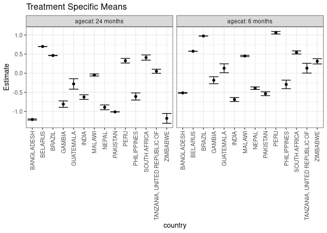

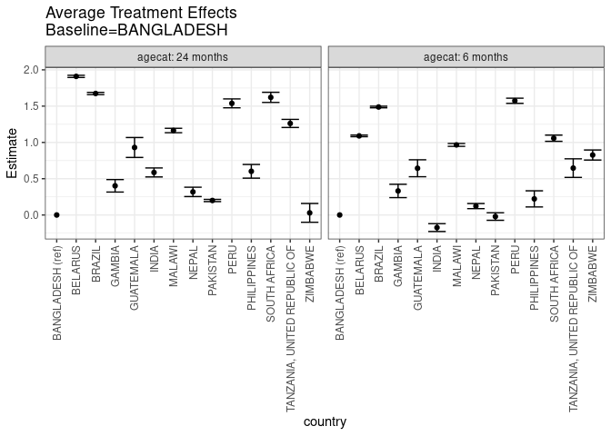

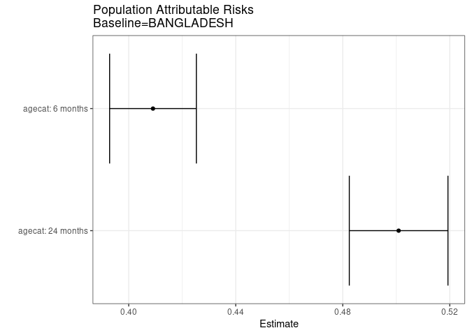

## Results Table

### Parameter: TSM

| agecat | intervention_level | baseline_level | estimate | ci_lower | ci_upper |
| --- | --- | --- | --- | --- | --- |
| 6 months | BANGLADESH | NA | -0.5158698 | -0.5268877 | -0.5048520 |
| 6 months | BELARUS | NA | 0.5741099 | 0.5738264 | 0.5743935 |
| 6 months | BRAZIL | NA | 0.9720774 | 0.9707548 | 0.9733999 |
| 6 months | GAMBIA | NA | -0.1846038 | -0.2760585 | -0.0931490 |
| 6 months | GUATEMALA | NA | 0.1281933 | 0.0117423 | 0.2446444 |
| 6 months | INDIA | NA | -0.6893944 | -0.7422958 | -0.6364930 |
| 6 months | MALAWI | NA | 0.4499404 | 0.4340086 | 0.4658723 |
| 6 months | NEPAL | NA | -0.3931312 | -0.4265699 | -0.3596926 |
| 6 months | PAKISTAN | NA | -0.5370575 | -0.5878211 | -0.4862940 |
| 6 months | PERU | NA | 1.0579686 | 1.0239414 | 1.0919957 |
| 6 months | PHILIPPINES | NA | -0.2938433 | -0.4045814 | -0.1831052 |
| 6 months | SOUTH AFRICA | NA | 0.5421785 | 0.5006517 | 0.5837052 |
| 6 months | TANZANIA, UNITED REPUBLIC OF | NA | 0.1303645 | 0.0027471 | 0.2579818 |
| 6 months | ZIMBABWE | NA | 0.3105514 | 0.2422554 | 0.3788475 |
| 24 months | BANGLADESH | NA | -1.2118562 | -1.2266521 | -1.1970603 |
| 24 months | BELARUS | NA | 0.6981406 | 0.6966133 | 0.6996680 |
| 24 months | BRAZIL | NA | 0.4626233 | 0.4583001 | 0.4669464 |
| 24 months | GAMBIA | NA | -0.8099290 | -0.8946036 | -0.7252543 |
| 24 months | GUATEMALA | NA | -0.2815804 | -0.4180323 | -0.1451285 |
| 24 months | INDIA | NA | -0.6257618 | -0.6857875 | -0.5657360 |
| 24 months | MALAWI | NA | -0.0477709 | -0.0743841 | -0.0211577 |
| 24 months | NEPAL | NA | -0.8935152 | -0.9562473 | -0.8307830 |
| 24 months | PAKISTAN | NA | -1.0120238 | -1.0149438 | -1.0091038 |
| 24 months | PERU | NA | 0.3264406 | 0.2668032 | 0.3860781 |
| 24 months | PHILIPPINES | NA | -0.6099592 | -0.7031852 | -0.5167331 |
| 24 months | SOUTH AFRICA | NA | 0.4090301 | 0.3406283 | 0.4774319 |
| 24 months | TANZANIA, UNITED REPUBLIC OF | NA | 0.0499394 | -0.0036944 | 0.1035732 |
| 24 months | ZIMBABWE | NA | -1.1825404 | -1.3111845 | -1.0538964 |

### Parameter: E(Y)

| agecat | intervention_level | baseline_level | estimate | ci_lower | ci_upper |
| --- | --- | --- | --- | --- | --- |
| 6 months | NA | NA | -0.1067985 | -0.1215768 | -0.0920202 |
| 24 months | NA | NA | -0.7109539 | -0.7278520 | -0.6940558 |

### Parameter: ATE

| agecat | intervention_level | baseline_level | estimate | ci_lower | ci_upper |
| --- | --- | --- | --- | --- | --- |
| 6 months | BANGLADESH | BANGLADESH | 0.0000000 | 0.0000000 | 0.0000000 |
| 6 months | BELARUS | BANGLADESH | 1.0899797 | 1.0789581 | 1.1010014 |
| 6 months | BRAZIL | BANGLADESH | 1.4879472 | 1.4768486 | 1.4990458 |
| 6 months | GAMBIA | BANGLADESH | 0.3312660 | 0.2391617 | 0.4233704 |
| 6 months | GUATEMALA | BANGLADESH | 0.6440632 | 0.5270956 | 0.7610307 |
| 6 months | INDIA | BANGLADESH | -0.1735246 | -0.2275612 | -0.1194879 |
| 6 months | MALAWI | BANGLADESH | 0.9658102 | 0.9464306 | 0.9851899 |
| 6 months | NEPAL | BANGLADESH | 0.1227386 | 0.0875191 | 0.1579581 |
| 6 months | PAKISTAN | BANGLADESH | -0.0211877 | -0.0731512 | 0.0307757 |
| 6 months | PERU | BANGLADESH | 1.5738384 | 1.5380695 | 1.6096073 |
| 6 months | PHILIPPINES | BANGLADESH | 0.2220265 | 0.1107417 | 0.3333114 |
| 6 months | SOUTH AFRICA | BANGLADESH | 1.0580483 | 1.0150979 | 1.1009987 |
| 6 months | TANZANIA, UNITED REPUBLIC OF | BANGLADESH | 0.6462343 | 0.5181470 | 0.7743216 |
| 6 months | ZIMBABWE | BANGLADESH | 0.8264213 | 0.7572415 | 0.8956010 |
| 24 months | BANGLADESH | BANGLADESH | 0.0000000 | 0.0000000 | 0.0000000 |
| 24 months | BELARUS | BANGLADESH | 1.9099968 | 1.8951213 | 1.9248724 |
| 24 months | BRAZIL | BANGLADESH | 1.6744795 | 1.6590648 | 1.6898942 |
| 24 months | GAMBIA | BANGLADESH | 0.4019272 | 0.3159648 | 0.4878896 |
| 24 months | GUATEMALA | BANGLADESH | 0.9302758 | 0.7930240 | 1.0675276 |
| 24 months | INDIA | BANGLADESH | 0.5860944 | 0.5242570 | 0.6479318 |
| 24 months | MALAWI | BANGLADESH | 1.1640853 | 1.1336115 | 1.1945592 |
| 24 months | NEPAL | BANGLADESH | 0.3183410 | 0.2538175 | 0.3828646 |
| 24 months | PAKISTAN | BANGLADESH | 0.1998324 | 0.1847588 | 0.2149060 |
| 24 months | PERU | BANGLADESH | 1.5382968 | 1.4768788 | 1.5997149 |
| 24 months | PHILIPPINES | BANGLADESH | 0.6018970 | 0.5075041 | 0.6962899 |
| 24 months | SOUTH AFRICA | BANGLADESH | 1.6208863 | 1.5508933 | 1.6908793 |
| 24 months | TANZANIA, UNITED REPUBLIC OF | BANGLADESH | 1.2617956 | 1.2061361 | 1.3174551 |
| 24 months | ZIMBABWE | BANGLADESH | 0.0293158 | -0.1001777 | 0.1588093 |

### Parameter: PAR

| agecat | intervention_level | baseline_level | estimate | ci_lower | ci_upper |
| --- | --- | --- | --- | --- | --- |
| 6 months | BANGLADESH | NA | 0.4090713 | 0.3928596 | 0.4252831 |
| 24 months | BANGLADESH | NA | 0.5009023 | 0.4824662 | 0.5193384 |